# Лабораторная работа №4

Работа с репозиториями git: Gitflow и общепринятые коммиты

Липатников Андрей

1032253853@rudn.ru

Российский университет дружбы народов

2026-10-07

# Информация

## Докладчик

- Липатников Андрей
- Студент Российского университета дружбы народов им. П. Лумумбы
- 1032253853@rudn.ru

# Вводная часть

## Актуальность

- Современная разработка ведётся командами: релизы и новая функциональность идут параллельно
- Без строгой модели ветвления история проекта превращается в запутанный набор коммитов
- Gitflow упорядочивает процесс, а Conventional Commits и SemVer автоматизируют версионирование
- Весь практикум курса сдаётся через git-репозиторий

## Объект и предмет исследования

- **Объект**: процессы управления версиями и организации рабочего процесса в git
- **Предмет**: применение Gitflow, общепринятых коммитов и семантического версионирования в тестовом репозитории git-extended
- **Критерий результата**: опубликованные релизы v1.0.0 и v1.2.3 с журналом изменений

## Цели и задачи

- Цель:
  - Получить навыки правильной работы с репозиториями git.
- Задачи:
  - Установить ПО: git-flow, Node.js, pnpm, commitizen, standard-changelog.
  - Создать тестовый репозиторий git-extended и настроить общепринятые коммиты.
  - Развернуть git-flow и сформировать релизы 1.0.0 и 1.2.3 с журналом изменений.

# Материалы и методы

## Используемое ПО и среда

- **Среда**: Fedora 41 (Sway) в VirtualBox (окружение из лабораторной работы №1)
- **Инструменты**:
  - `git-flow` — модель ветвления в виде команд
  - `pnpm`, `commitizen`, `standard-changelog` — общепринятые коммиты и changelog
  - `gh` — публикация релизов на GitHub
- **Тестовый репозиторий**: git-extended на GitHub

## Методика выполнения

- Установка и настройка инструментов
- Создание репозитория и конфигурация формата коммитов
- Инициализация git-flow (префикс тегов `v`)
- Полный цикл релизов 1.0.0 и 1.2.3: ветка release, журнал изменений, публикация
- Цикл работы с функциональной веткой

# Содержание исследования

## Установка инструментов

- git-flow установлен из Copr, Node.js и pnpm — из репозиториев Fedora
- Настройка окружения: `pnpm setup`, обновление PATH
- commitizen и standard-changelog установлены глобально

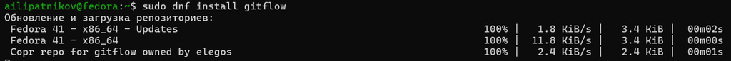

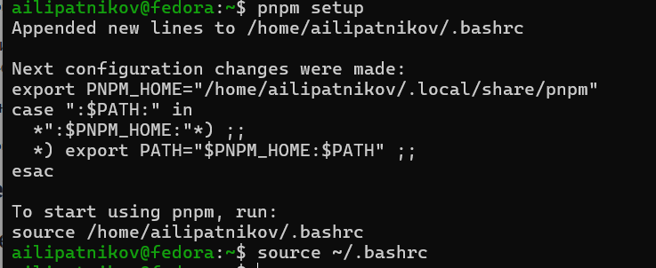

## Репозиторий и конфигурация коммитов

- Создан репозиторий git-extended на GitHub, выполнен первый коммит и push
- `pnpm init`, лицензия CC-BY-4.0, настройка commitizen в `package.json`
- Коммиты формируются через `git cz` в формате Conventional Commits

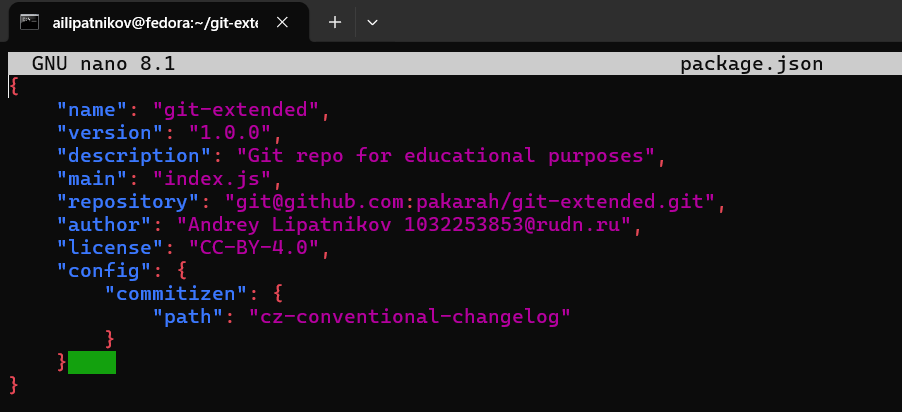

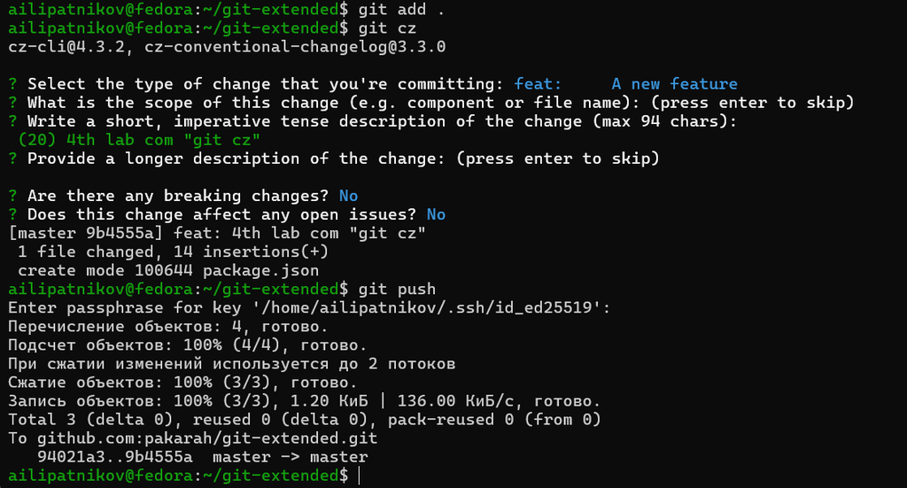

## Инициализация git-flow

- Выполнен `git flow init`, префикс ярлыков установлен в `v`
- Проверена ветка: после инициализации работа идёт в `develop`
- Репозиторий отправлен на GitHub, develop привязана к origin

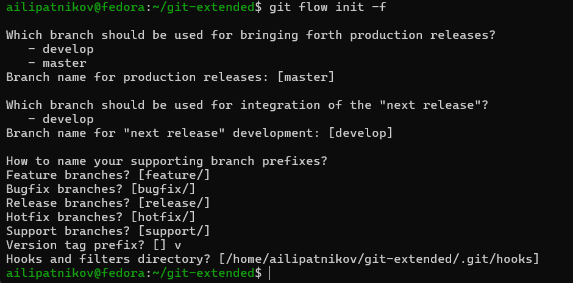

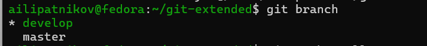

## Релиз 1.0.0

- `git flow release start 1.0.0` — создана релизная ветка
- Журнал изменений: `standard-changelog --first-release`
- Слияние с master, публикация веток и тегов

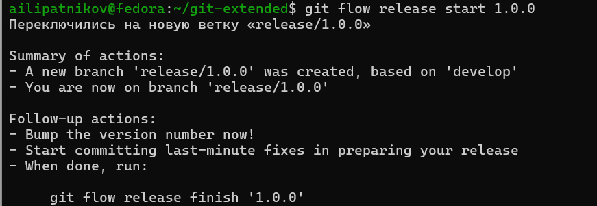

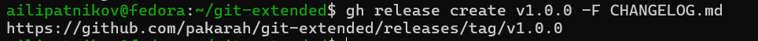

## Функциональная ветка и релиз 1.2.3

- Цикл: `git flow feature start` … `git flow feature finish` — ветка слита с develop
- Релиз 1.2.3: версия обновлена в `package.json`, changelog сгенерирован заново
- Релиз v1.2.3 опубликован на GitHub

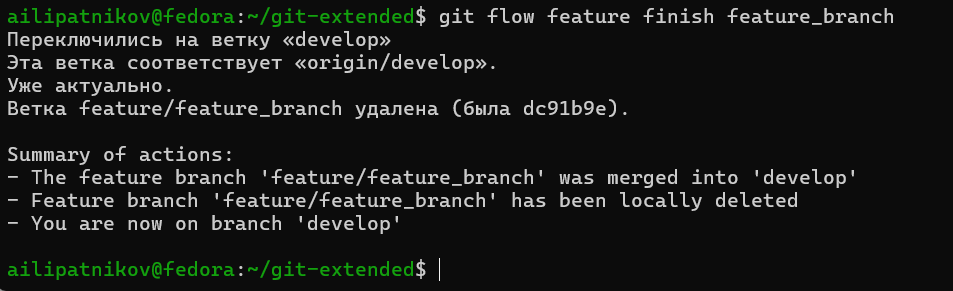

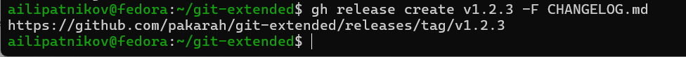

# Результаты

## Полученные результаты

- Репозиторий git-extended преобразован в git-flow с общепринятыми коммитами

| Результат | Значение |
| --- | --- |
| Ветки | `master`, `develop`, `feature`, `release` |
| Префикс тегов | `v` |
| Формат коммитов | Conventional Commits (`git cz`) |
| Публикации | релизы `v1.0.0` и `v1.2.3` с `CHANGELOG.md` |

# Заключение